# HR Case Study Analysis

Paul Kim

12/12/2018

### Introduction

This analysis is based on data from ABC Company’s Employee Engagement Survey, which measures employee engagement levels across all of ABC Company’s international divisions. The survey consists of 20 questions that examine an employee’s overall satisfaction at work in regards to relationships with peers and supervisors, sense of happiness and purpose within one’s work, opportunities for learning and development, and more. Employee engagement is a strong testament to the organizational culture of the company.

### Method

Here is the schema of the data:

1. *REGION*: Country in which the survey was conducted.
2. *QUESTION*: Categorical variable with the number of the question that was asked.
3. *SCORE*: Value received for the question, out of 5 possible points.
4. *COLOR*: Color of the tile for the specific question, which corresponds to quartile rank.
5. *GREEN*: Ordinal categorical variable detailing whether tile color is green or dark green. Dark green tiles receive a value of 2, green tiles receive a value of 1, and all others receive 0 - no reward for mediocrity.
6. *TEXT*: The text of the question.
7. *zSCORE*: Standardized value for question score. Standardizing a variable allows us to see how far a value is from the mean.
8. *CATEGORY*: The category of the question, divided between culture, peer, and management.

### Pre-Analysis

Before diving deeper, here is the overall distribution of scores across the data:

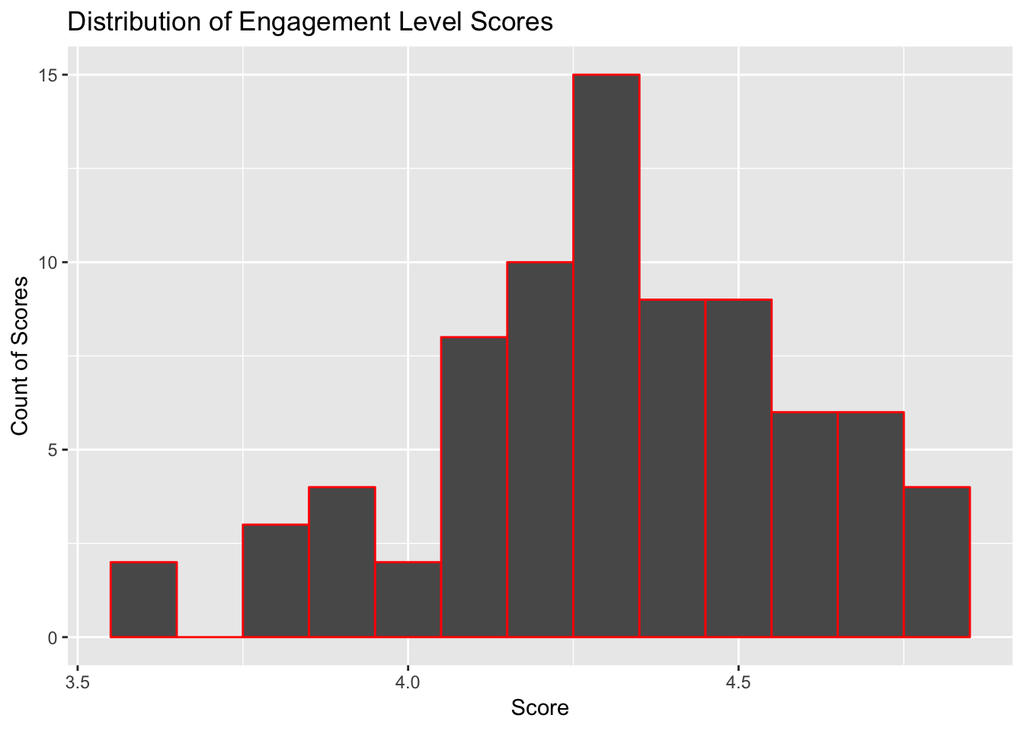

Here are some sample statistics of the data:

- Mean: 4.32
- Median: 4.3
- Std. dev: 0.28
- Interquartile Range (IQR): 0.3

When examining the histogram, we can see that our data seem to be centered around a score of 4.3, which matches our sample statistics. Since the values are similar, we have evidence that the data are not overly influenced by outliers. Also, based on the IQR, scores seem to typically fall between 4.15 and 4.45, meaning that for *our* data, any score 4.5 and above are in the top quartile, and any score below 4.1 is in the bottom 25%, which may be different for the industry-wide quartile rankings. Based on the quartile rankings in the original data, ABC Company likely ranks in the upper 50% amongst its peers.

### Analysis 1: Engagement by Region

Here are the average engagement level scores for each country:

| Group.1 | SCORE |
| --- | --- |
| Colombia | 4.530769 |
| Brazil | 4.392308 |
| Chile | 4.300000 |
| NA | 4.300000 |
| Peru | 4.246154 |
| Mexico | 4.123077 |

Colombia has the strongest scores, followed by Brazil. Chile and North America exhibit average marks while Peru and Mexico round out the bottom, albeit Peru’s engagement is close to the average. However, Colombia does not exhibit exceptionally great engagement levels, nor does Mexico demonstrate significantly low engagement, as their averages both lie within one standard deviation of the mean. We can see this by examining *zSCORE* for each region:

| Group.1 | zSCORE |
| --- | --- |
| Colombia | 0.77799610 |
| Brazil | 0.27785575 |
| NA | -0.05557115 |
| Chile | -0.05557115 |
| Peru | -0.25007018 |
| Mexico | -0.69463938 |

We can also examine the distribution of scores using a boxplot:

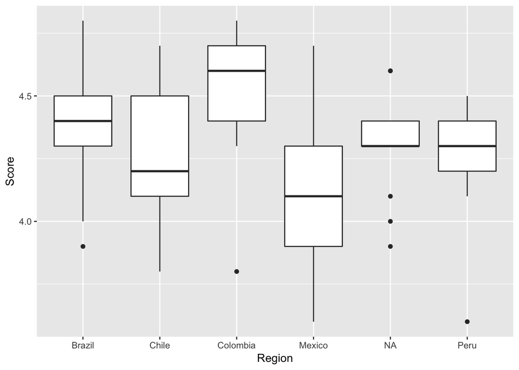

Based on the plot, Colombian employees are the most satisfied (aside from one aspect of working), while North America has the most consistent responses. The Mexico office has the most dissatisfactory and polarized working experience.Therefore, my immediate recommendation would be to explore the organizational and cultural characteristics of the Mexico office.

When examining the scores for Mexico, its highest score (4.7) was for Q10 while its lowest (3.6) was for Q6. It seems that employees in Mexico overall have great relationships with each other, but can do better in terms of pushing one another professionally.

In order to examine which aspects of our overall culture are strong and which can be improved, we need to analyze the scores of the questions themselves.

### Analysis 2: Overall Engagement

Here are the average engagement level scores by survey question. Please note the average score across the data is 4.32:

| Group.1 | SCORE |
| --- | --- |
| 0 | 4.566667 |
| 8 | 4.550000 |
| 10 | 4.500000 |
| 4 | 4.416667 |
| 11 | 4.333333 |
| 1 | 4.316667 |
| 12 | 4.316667 |
| 3 | 4.283333 |
| 9 | 4.283333 |
| 5 | 4.266667 |

[output cut: 3 more lines]

Here are the three questions that averaged the highest:

- Q00. *How satisfied are you with ABC as a place to work?* (4.57)
- Q08. *I feel a sense of purpose in my work.* (4.55)
- Q10. *I get along with my peers.* (4.50)

And the three that averaged the lowest:

- Q06. *My manager cares about my development.* (4.00)
- Q02. *I have the tools I need to do well at work.* (4.02)
- Q07. *My opinions matter at work.* (4.25)

Based on these results, we can infer that overall, employees enjoy working for ABC Company, yet the company’s accommodations for their workers can be improved. Furthermore, we can do a better job of being more encouraging and intentional with our peers.

I also examined the overall distribution of answers for each question:

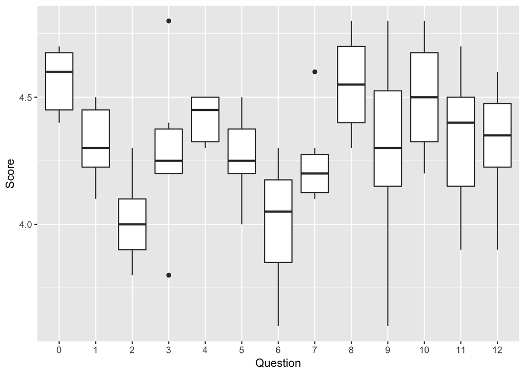

Based on the plot, Questions 2 and 6 receive the poorest marks, but another question I’d like to highlight is Question 9, which pertains to the quality of work being produced by employees. Having such volatile responses presents a problem for ABC Company as a whole; it is important that the work we deliver to our clients is not only of the best quality, but consistent throughout all our divisions.

The lowest value for Question 9, *3.6*, was scored by the Peruvian office. Since this issue is pertinent in the Peru office, if we can improve the outcome for this measure, the overall response for this question would be positive; all other offices scored relatively well. This may be a cultural issue for the specific office; maybe employees aren’t great at appreciating or respecting each other. Perhaps implementing training or a peer reward system (if not in place) could be a potential response.

Furthermore, to get a better understanding of the overall issues that are hurting the organization, here is the average of scores calculated by question type:

| Group.1 | SCORE |
| --- | --- |
| culture | 4.462500 |
| peer | 4.391667 |
| management | 4.209524 |

Overall, management for our employees is the primary focus for improvement. By improving certain managerial tactics, we can begin to cultivate more positive relationships between employers and peers, thereby creating a better culture promote higher levels of employee engagement.

### Summary of Results

- Overall engagement for ABC Company is likely in the upper 50% industry-wide.
- Colombia is the most engaged office, whereas Mexico is the least engaged office. Colombia scored well on all marks except one professional development question whereas Mexico’s lowest responses pertained to office accommodations and professional development. Overall, we need to examine the professional review and development system in place in successful offices such as Colombia and benchmark the process for Mexico. Furthermore, we need to ensure that employee requests are adequately met so they can do their jobs effectively and efficiently.
- Questions 2 and 6 received the lowest scores, but Question 9 had the most polarized opinions. The Peru office may have a cultural issue which can be resolved with a peer reward or feedback system.
- Firmwide, ABC Company should make sure that it offers sufficient accommodations for its employees and to cultivate a culture that not only encourages workers but challenges them personally and professionally. Furthermore, ABC Company should ensure the quality of work is consistent and excellent throughout the organization.